# RED WINE QUALITY ANALYSIS by ANTONY

```r
# Load the Data

df = read.csv('wineQualityReds.csv')

#Read the Dataset

head(df,5)
```

```
##   X fixed.acidity volatile.acidity citric.acid residual.sugar chlorides
## 1 1           7.4             0.70        0.00            1.9     0.076
## 2 2           7.8             0.88        0.00            2.6     0.098
## 3 3           7.8             0.76        0.04            2.3     0.092
## 4 4          11.2             0.28        0.56            1.9     0.075
## 5 5           7.4             0.70        0.00            1.9     0.076
##   free.sulfur.dioxide total.sulfur.dioxide density   pH sulphates alcohol
## 1                  11                   34  0.9978 3.51      0.56     9.4
## 2                  25                   67  0.9968 3.20      0.68     9.8
## 3                  15                   54  0.9970 3.26      0.65     9.8
## 4                  17                   60  0.9980 3.16      0.58     9.8
## 5                  11                   34  0.9978 3.51      0.56     9.4
##   quality
## 1       5
## 2       5
## 3       5
## 4       6
## 5       5
```

# Introduction:

In this Project, I will be Analyzing the Red Wine Dataset to understand how the different variables in the dataset impacts the quality of the wine.In my Analysis, Intially I will be exploring the variables indiviually and then I will explore the corelation between the variables.

# Univariate Plots Section:

```r
#Structure of the Dataset

str(df)
```

```
## 'data.frame':    1599 obs. of  13 variables:
##  $ X                   : int  1 2 3 4 5 6 7 8 9 10 ...
##  $ fixed.acidity       : num  7.4 7.8 7.8 11.2 7.4 7.4 7.9 7.3 7.8 7.5 ...
##  $ volatile.acidity    : num  0.7 0.88 0.76 0.28 0.7 0.66 0.6 0.65 0.58 0.5 ...
##  $ citric.acid         : num  0 0 0.04 0.56 0 0 0.06 0 0.02 0.36 ...
##  $ residual.sugar      : num  1.9 2.6 2.3 1.9 1.9 1.8 1.6 1.2 2 6.1 ...
##  $ chlorides           : num  0.076 0.098 0.092 0.075 0.076 0.075 0.069 0.065 0.073 0.071 ...
##  $ free.sulfur.dioxide : num  11 25 15 17 11 13 15 15 9 17 ...
##  $ total.sulfur.dioxide: num  34 67 54 60 34 40 59 21 18 102 ...
##  $ density             : num  0.998 0.997 0.997 0.998 0.998 ...
##  $ pH                  : num  3.51 3.2 3.26 3.16 3.51 3.51 3.3 3.39 3.36 3.35 ...
##  $ sulphates           : num  0.56 0.68 0.65 0.58 0.56 0.56 0.46 0.47 0.57 0.8 ...
##  $ alcohol             : num  9.4 9.8 9.8 9.8 9.4 9.4 9.4 10 9.5 10.5 ...
##  $ quality             : int  5 5 5 6 5 5 5 7 7 5 ...
```

```r
#Summary of the dataset

summary(df)
```

```
##        X          fixed.acidity   volatile.acidity  citric.acid
##  Min.   :   1.0   Min.   : 4.60   Min.   :0.1200   Min.   :0.000
##  1st Qu.: 400.5   1st Qu.: 7.10   1st Qu.:0.3900   1st Qu.:0.090
##  Median : 800.0   Median : 7.90   Median :0.5200   Median :0.260
##  Mean   : 800.0   Mean   : 8.32   Mean   :0.5278   Mean   :0.271
##  3rd Qu.:1199.5   3rd Qu.: 9.20   3rd Qu.:0.6400   3rd Qu.:0.420
##  Max.   :1599.0   Max.   :15.90   Max.   :1.5800   Max.   :1.000
##  residual.sugar     chlorides       free.sulfur.dioxide
##  Min.   : 0.900   Min.   :0.01200   Min.   : 1.00
##  1st Qu.: 1.900   1st Qu.:0.07000   1st Qu.: 7.00
##  Median : 2.200   Median :0.07900   Median :14.00
##  Mean   : 2.539   Mean   :0.08747   Mean   :15.87
##  3rd Qu.: 2.600   3rd Qu.:0.09000   3rd Qu.:21.00
##  Max.   :15.500   Max.   :0.61100   Max.   :72.00
##  total.sulfur.dioxide    density             pH          sulphates
##  Min.   :  6.00       Min.   :0.9901   Min.   :2.740   Min.   :0.3300
##  1st Qu.: 22.00       1st Qu.:0.9956   1st Qu.:3.210   1st Qu.:0.5500
##  Median : 38.00       Median :0.9968   Median :3.310   Median :0.6200
##  Mean   : 46.47       Mean   :0.9967   Mean   :3.311   Mean   :0.6581
##  3rd Qu.: 62.00       3rd Qu.:0.9978   3rd Qu.:3.400   3rd Qu.:0.7300
##  Max.   :289.00       Max.   :1.0037   Max.   :4.010   Max.   :2.0000
##     alcohol         quality
##  Min.   : 8.40   Min.   :3.000
##  1st Qu.: 9.50   1st Qu.:5.000
##  Median :10.20   Median :6.000
##  Mean   :10.42   Mean   :5.636
##  3rd Qu.:11.10   3rd Qu.:6.000
##  Max.   :14.90   Max.   :8.000
```

# Univariate Analysis:

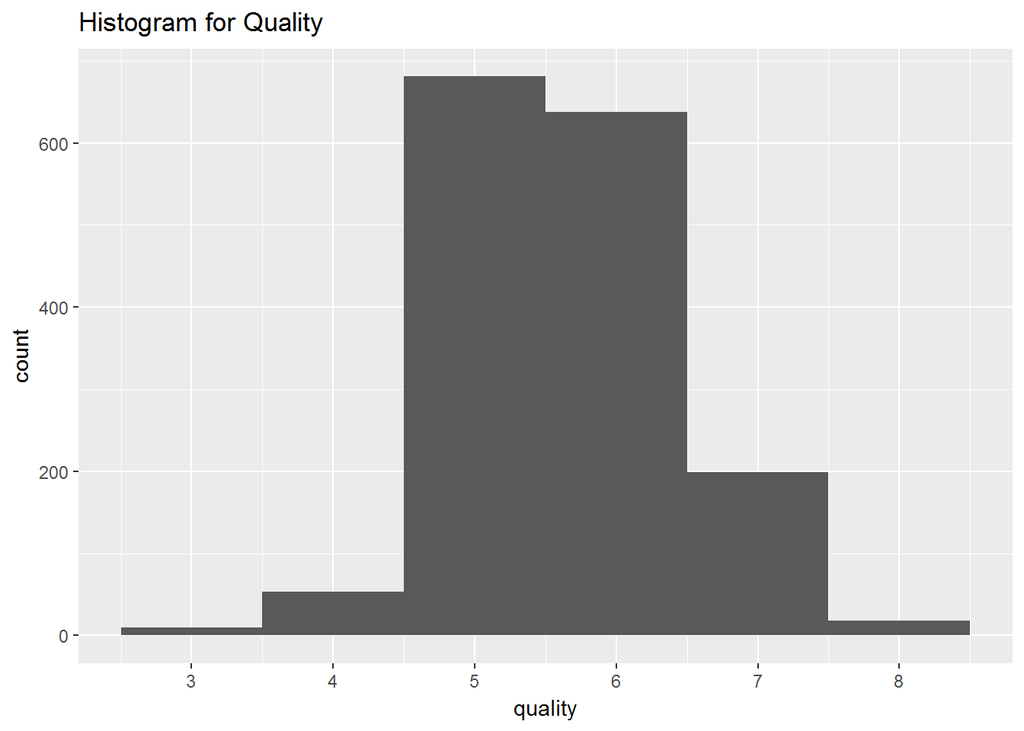

```r
#Histogram for Quality

qplot(x=quality,data=df,binwidth = 1,
      main='Histogram for Quality')+
  scale_x_continuous(breaks=seq(2,8,1))
```

> One thing, I am noticing in the above plot is the most of the wines are fall under the quality of 5 and 6.so what am thiking it’s make sense to create a new categorical variable from this quality variable.

```r
#Adding a new Variable Rating

df$rating <- ifelse(df$quality < 5, 'Bad', ifelse(
  df$quality < 7, 'Average', 'Good'))

#Order the rating variable

df$rating <-ordered(df$rating,
                    levels =c('Bad','Average','Good'))
```

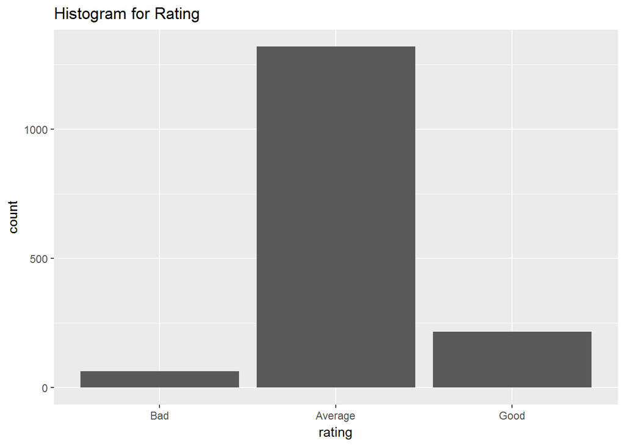

```r
#Histogram for Rating

qplot(x=rating,data=df,,main='Histogram for Rating')
```

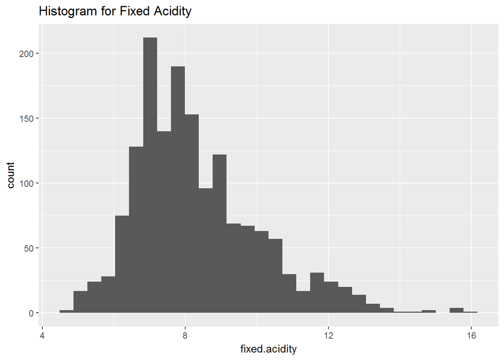

```r
#Histogram for Fixed Acidity

qplot(x=fixed.acidity,data=df,main='Histogram for Fixed Acidity')
```

> The above Fixed Acididty plot is right skewed. There are outliers present in the plot.Let’s remove the outliers and rescale the plot.

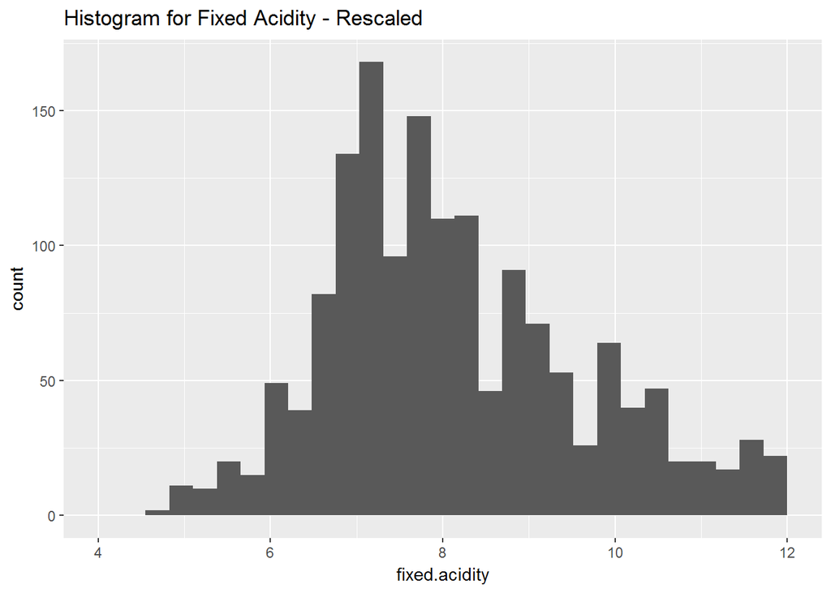

```r
#Fixed Acidity (Remove Outliers)

qplot(x=fixed.acidity,data=df,
      main='Histogram for Fixed Acidity - Rescaled')+
  scale_x_continuous(limit=c(4,12),breaks=seq(4,12,2))
```

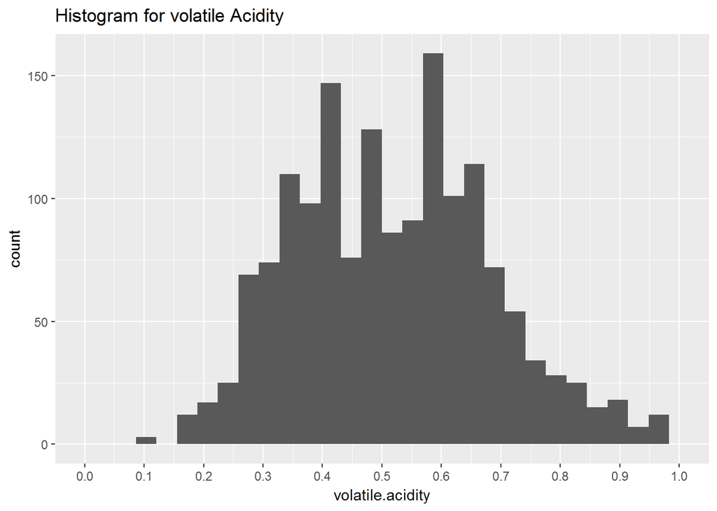

```r
#VOlatile Acidity

qplot(x=volatile.acidity,data=df,
      main='Histogram for volatile Acidity')+
  scale_x_continuous(limit=c(0,1),breaks=seq(0,11,0.1))
```

> The Above plot has been rescaled to remove outliers.The below bimodal distribution has three peaks at 0.4,0.5 and 0.6

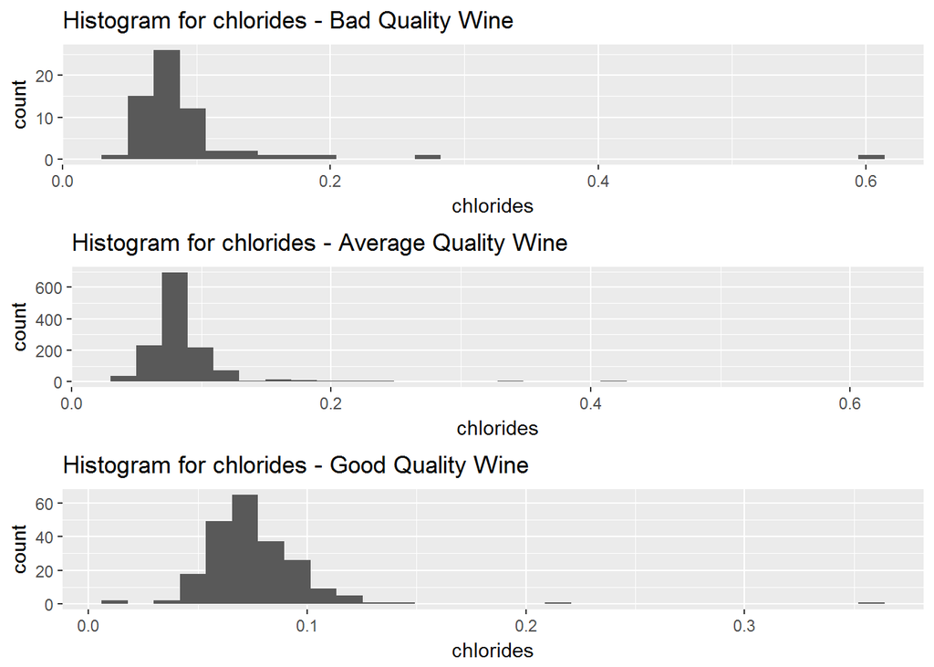

```r
# Compare Salt content based on the rating of the wine

p1 <- qplot(x=chlorides , data = subset(df,df$rating == 'Bad'),
            main='Histogram for chlorides - Bad Quality Wine')

p2 <- qplot(x=chlorides , data = subset(df,df$rating == 'Average'),
            main='Histogram for chlorides - Average Quality Wine')

p3 <- qplot(x=chlorides , data = subset(df,df$rating == 'Good'),
            main='Histogram for chlorides - Good Quality Wine')

grid.arrange(p1,p2,p3)
```

> By looking at all the three plots based on the rating of the wine, The Amount of chlorides in the Average rating wine follows alomst a normal distribution if we remove the outlier.But whereas, the Bad and Good quality wines has a right skewed distributions with very high outliers which will certainly affect the mean.

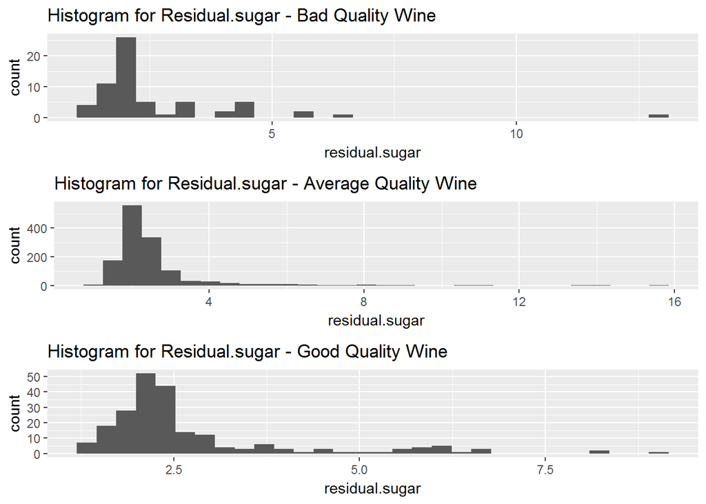

```r
#Residual Sugar

p4 <- qplot(x=residual.sugar , data = subset(df,df$rating == 'Bad'),
            main='Histogram for Residual.sugar - Bad Quality Wine')

p5 <- qplot(x=residual.sugar , data = subset(df,df$rating == 'Average'),
            main='Histogram for Residual.sugar - Average Quality Wine')

p6 <- qplot(x=residual.sugar , data = subset(df,df$rating == 'Good'),
            main='Histogram for Residual.sugar - Good Quality Wine')

grid.arrange(p4,p5,p6)
```

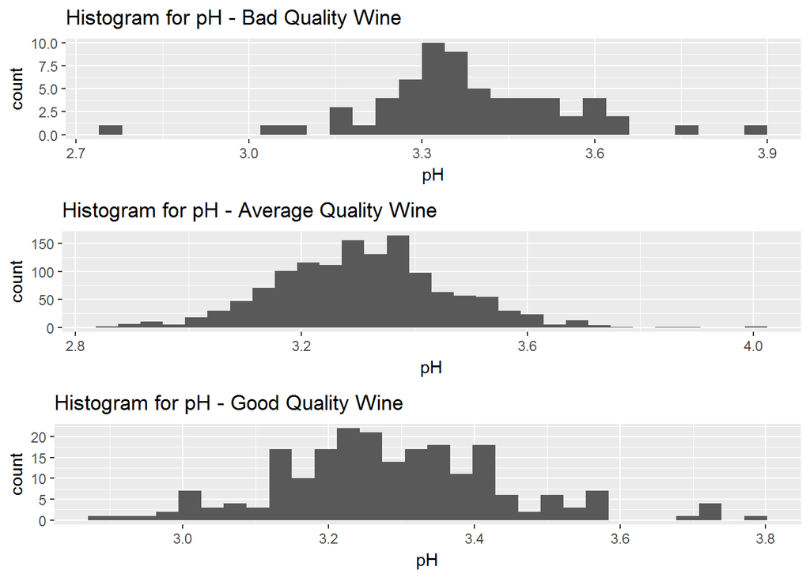

```r
#pH

p7 <- qplot(x=pH , data = subset(df,df$rating == 'Bad'),
            main='Histogram for pH - Bad Quality Wine')

p8 <- qplot(x=pH , data = subset(df,df$rating == 'Average'),
            main='Histogram for pH - Average Quality Wine')

p9 <- qplot(x=pH , data = subset(df,df$rating == 'Good'),
            main='Histogram for pH - Good Quality Wine')

grid.arrange(p7,p8,p9)
```

> Ph level does fall under 3-3.6 for most of the wines irrespective of their qualities.There are outliers in all the qualites of wine

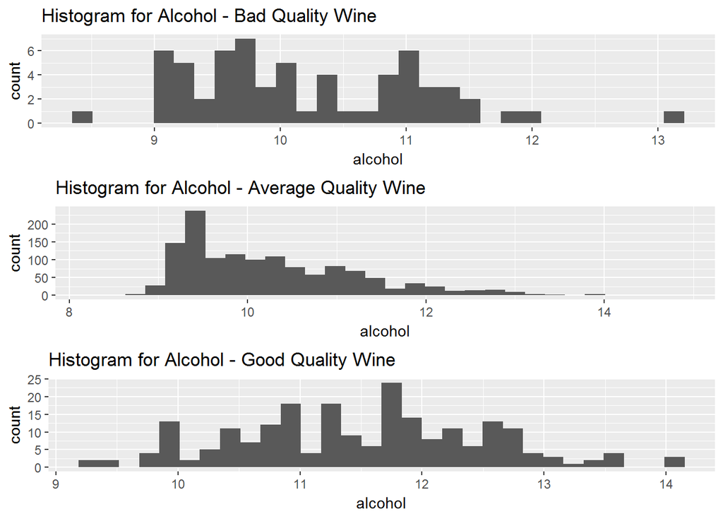

```r
#Alcohol

p10 <- qplot(x=alcohol , data = subset(df,df$rating == 'Bad'),
             main='Histogram for Alcohol - Bad Quality Wine')

p11 <- qplot(x=alcohol , data = subset(df,df$rating == 'Average'),
             main='Histogram for Alcohol - Average Quality Wine')

p12 <- qplot(x=alcohol , data = subset(df,df$rating == 'Good'),
             main='Histogram for Alcohol - Good Quality Wine')

grid.arrange(p10,p11,p12)
```

> For Alcohol, The distribution again is skewed with Outliers are present in the distirbution. Also the Alcohol content for most of the wines are between 9-12.

> Below is the log10 distribution of Alcohol.

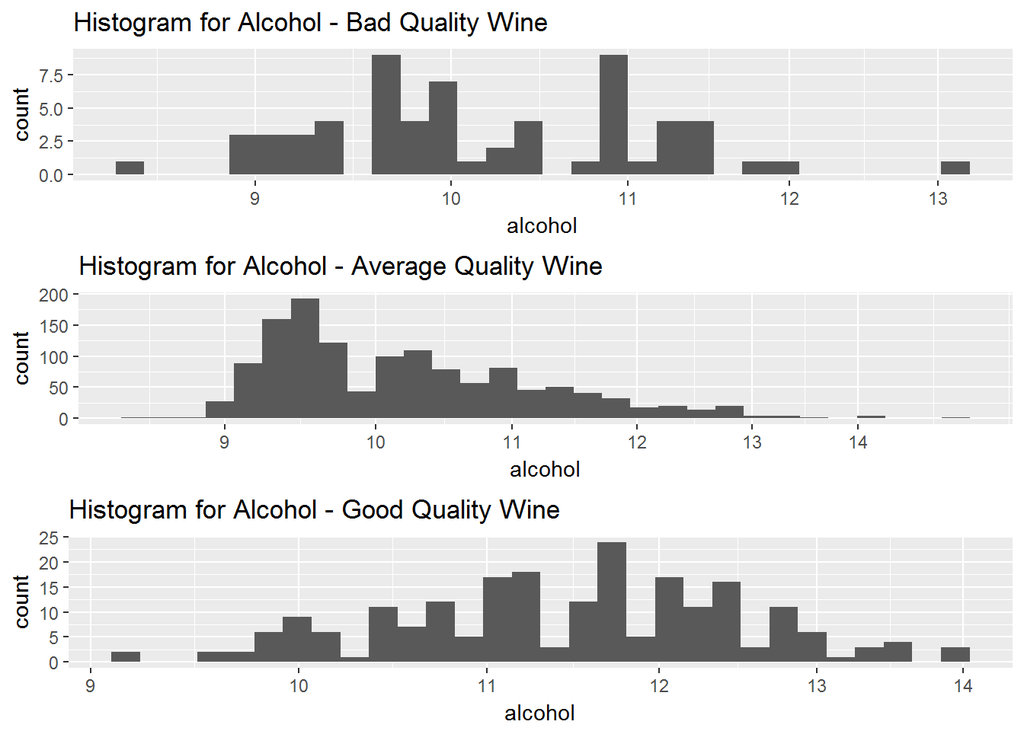

```r
#Alcohol Log10

p10 <- qplot(x=alcohol , data = subset(df,df$rating == 'Bad'),
             main='Histogram for Alcohol - Bad Quality Wine')+
              scale_x_log10(breaks = seq(8,14,1))

p11 <- qplot(x=alcohol , data = subset(df,df$rating == 'Average'),
             main='Histogram for Alcohol - Average Quality Wine')+
              scale_x_log10(breaks = seq(8,14,1))

p12 <- qplot(x=alcohol , data = subset(df,df$rating == 'Good'),
             main='Histogram for Alcohol - Good Quality Wine')+
              scale_x_log10(breaks = seq(8,14,1))

grid.arrange(p10,p11,p12)
```

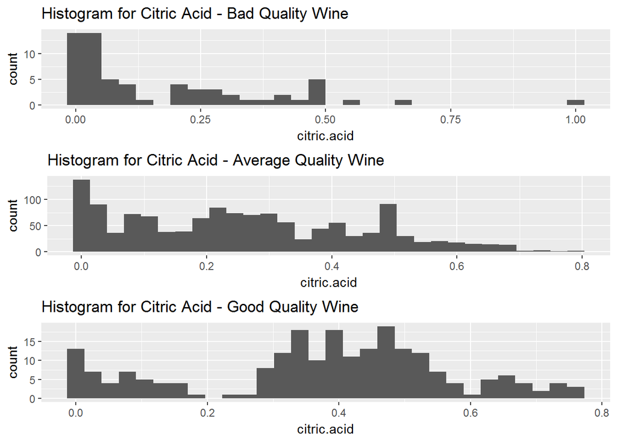

```r
#Citric Acid

p13 <- qplot(x=citric.acid , data = subset(df,df$rating == 'Bad'),
             main='Histogram for Citric Acid - Bad Quality Wine')


p14 <- qplot(x=citric.acid , data = subset(df,df$rating == 'Average'),
             main='Histogram for Citric Acid - Average Quality Wine')


p15 <- qplot(x=citric.acid , data = subset(df,df$rating == 'Good'),
             main='Histogram for Citric Acid - Good Quality Wine')


grid.arrange(p13,p14,p15)
```

> This distribution skewed with lots of Outliers.

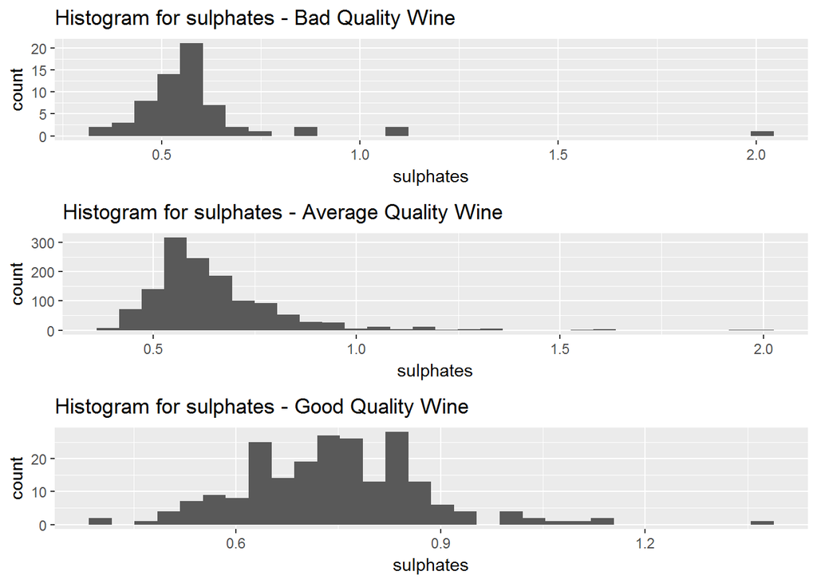

```r
#Suplhates

p16 <- qplot(x=sulphates , data = subset(df,df$rating == 'Bad'),
             main='Histogram for sulphates - Bad Quality Wine')


p17 <- qplot(x=sulphates , data = subset(df,df$rating == 'Average'),
             main='Histogram for sulphates - Average Quality Wine')


p18 <- qplot(x=sulphates , data = subset(df,df$rating == 'Good'),
             main='Histogram for sulphates - Good Quality Wine')


grid.arrange(p16,p17,p18)
```

> This is again a skewed distributin with less outliers.

### What is the structure of your dataset?

There are 1599 observations in the dataset with 14 variables(fixed.acidity, volatile.acidity,citric.acid,residual.sugar,chlorides,free.sulfur.dioxide,total.sulfur.dioxide,density,pH,sulphates,alcohol,quality,rating).The Quality and Rating are ordered variables with following levels

Bad —–> Good

Quality: 3,4,5,6,7,8 Rating: Bad,Average,Good.

Other Observations:

### What is/are the main feature(s) of interest in your dataset?

Quality and Rating are the main features in the dataset. we can explore the features like Alcohol,PH,Chlorides,Residual Sugar based on the quality and Rating.

Alcohol,PH,Chlorides,Residual Sugar,Fixed Acidity,Volatile Acidity are the other features in the dataset

### Did you create any new variables from existing variables in the dataset?

yes,I have created a new categorical variable called ‘Rating’ based on the Quality of the wine.

### Of the features you investigated, were there any unusual distributions?

yes, when i am exploring the indivual variables based on the quality, i found outliers and skewed distributions.

# Bivariate Plots Section

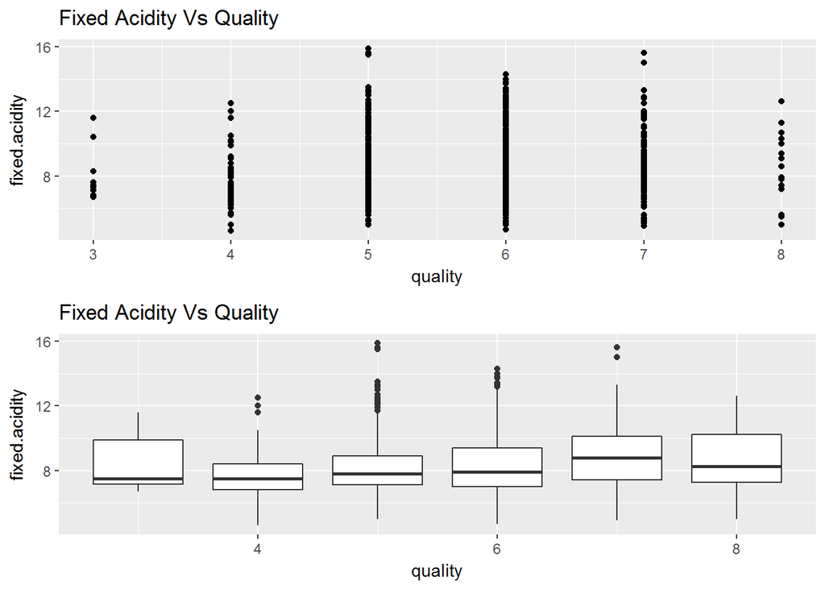

```r
#Fixed Acidity Vs Quality

p1 <- ggplot(aes(x=quality , y= fixed.acidity,group=quality), data=df)+
  geom_point()+ggtitle('Fixed Acidity Vs Quality')

p2 <- ggplot(aes(x=quality , y= fixed.acidity,group=quality), data=df)+
  geom_boxplot()+ggtitle('Fixed Acidity Vs Quality')

grid.arrange(p1,p2)
```

> Fixed Acidity doesnt have any co-realtion with Quality.Also Box plot gives us better understanding than scatter plot

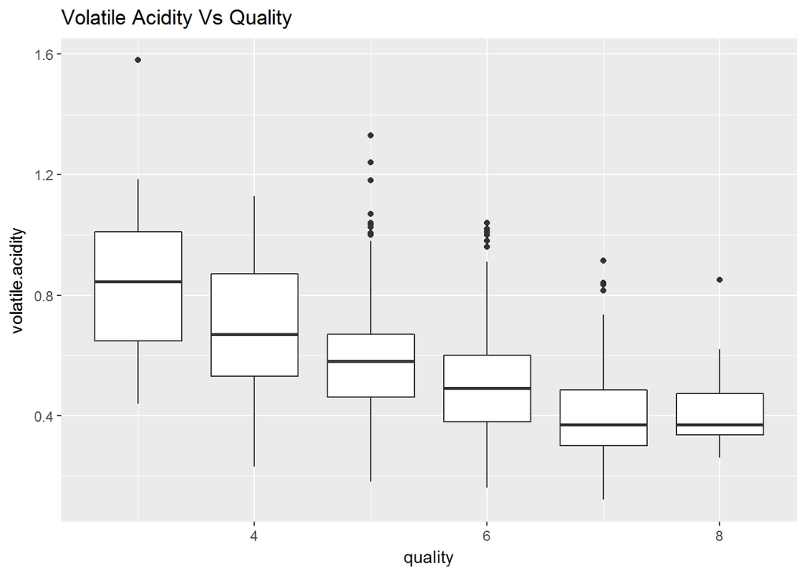

```r
#Volatile Acidity Vs Quality

ggplot(aes(x=quality , y= volatile.acidity,group=quality), data=df)+
  geom_boxplot()+ggtitle('Volatile Acidity Vs Quality')
```

> Volatile Acidity Vs Quality has a negative co-relation.As the quality increased the median of the volatile decreases.

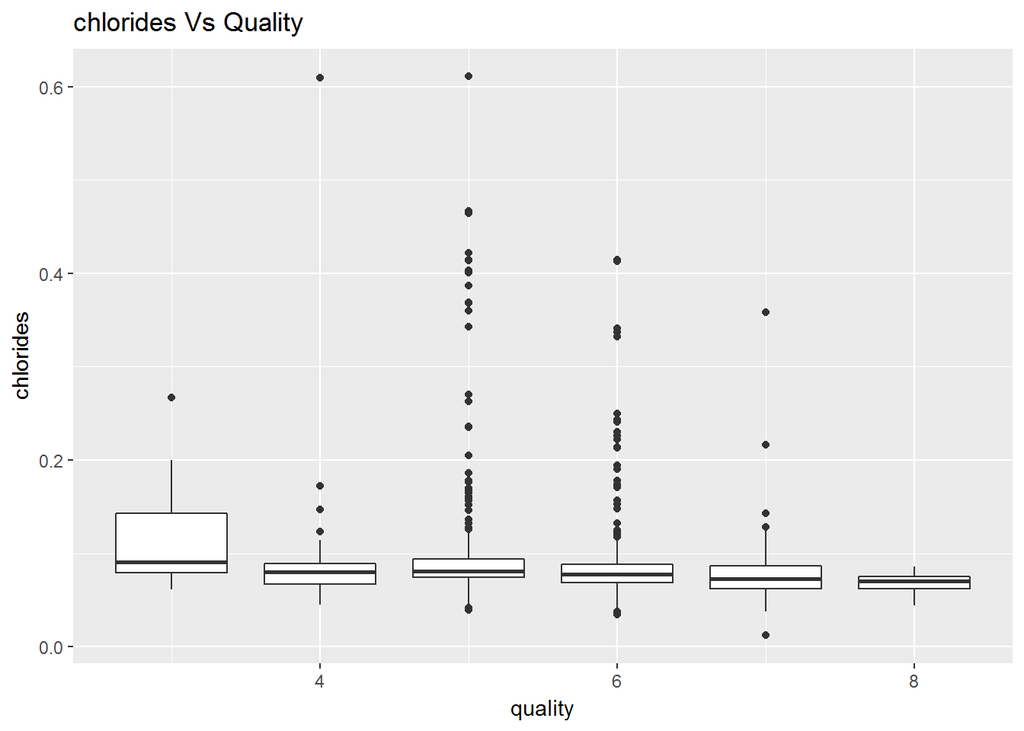

```r
#chlorides Vs Quality

ggplot(aes(x=quality , y= chlorides,group=quality), data=df)+
  geom_boxplot()+ggtitle('chlorides Vs Quality')
```

> chlorides has weakly co-related with Quality.As the median decreases,when the quality increases.so we can predict that better quality wines has lesser chlorides.

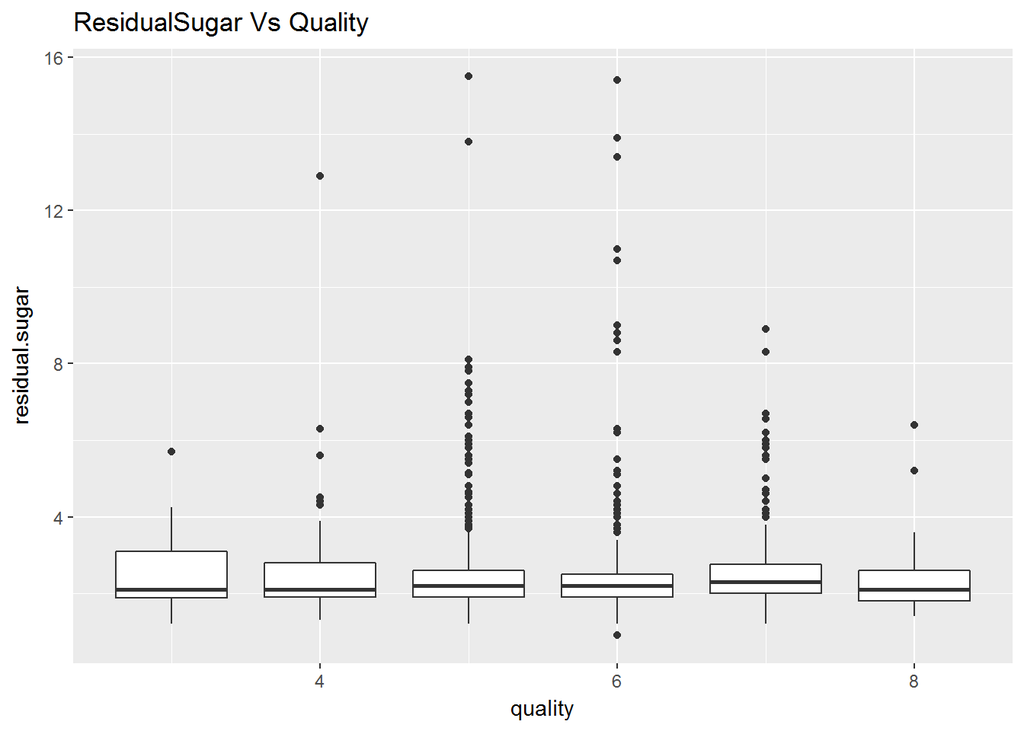

```r
#ResidualSugar Vs Quality

ggplot(aes(x=quality , y= residual.sugar,group=quality), data=df)+
  geom_boxplot()+ggtitle('ResidualSugar Vs Quality')
```

> Residual sugar has no relation with Quality. Also the Average quality wines has a very high outliers

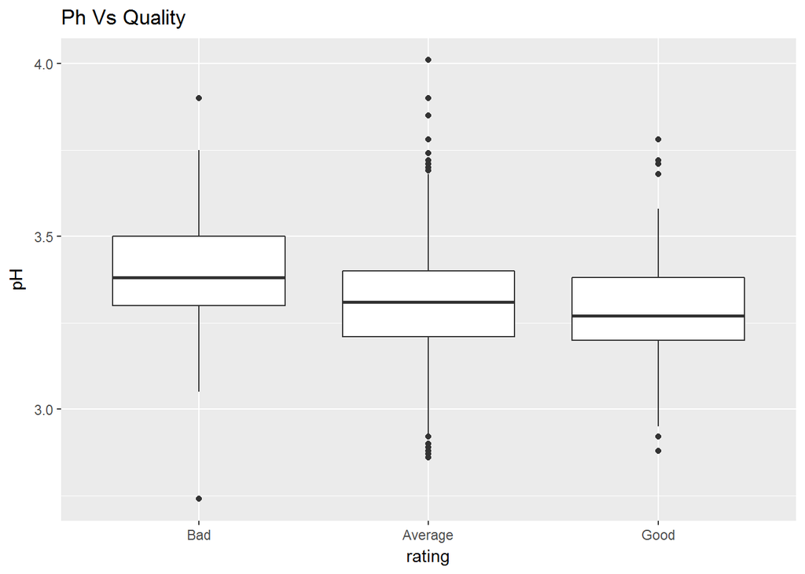

```r
#Ph Vs rating

ggplot(aes(x=rating , y= pH,group=rating), data=df)+
  geom_boxplot()+ggtitle('Ph Vs Quality')
```

> pH has a negative co-relation with Rating. As rating of the wine increases, pH vaue decreases.Also we can able to see the outliers

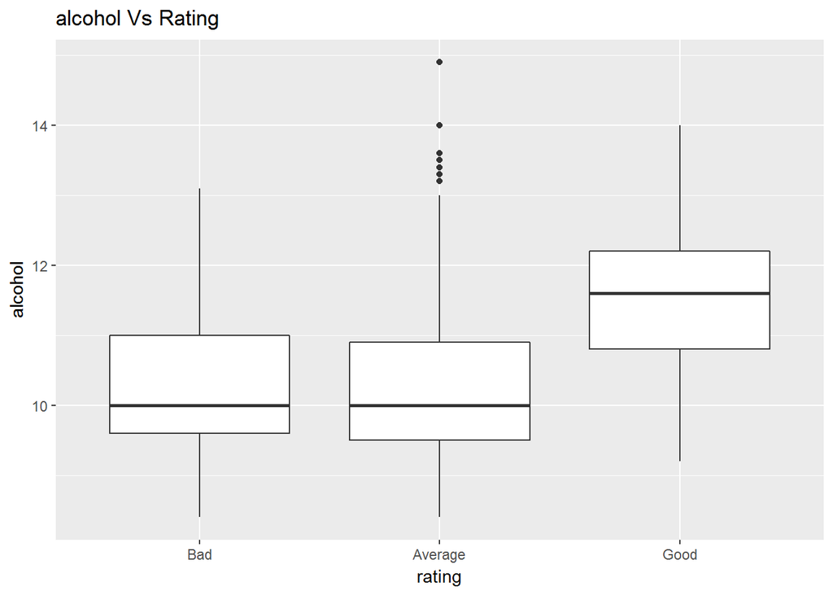

```r
ggplot(aes(x=rating , y= alcohol,group=rating), data=df)+
  geom_boxplot()+ggtitle('alcohol Vs Rating')
```

> Good wines has more alcohol content.Also, the median of Bad and Average rating wines are same.Also there are outliers present for Average rating wines.

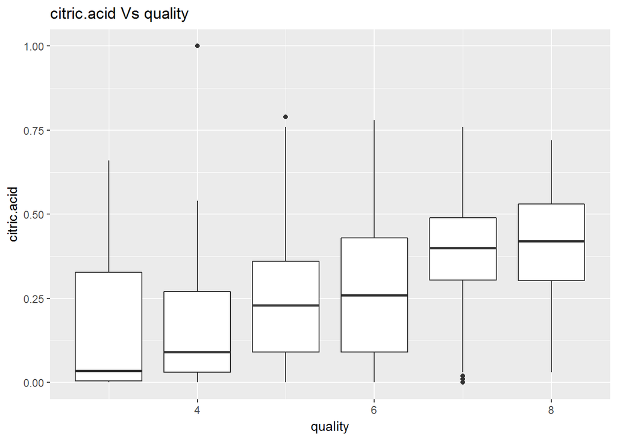

```r
#citric.acid Vs quality

ggplot(aes(x=quality , y= citric.acid,group=quality), data=df)+
  geom_boxplot()+ggtitle('citric.acid Vs quality')
```

> Wow!. Citric Acid has a strong postive reltionship with Quality.

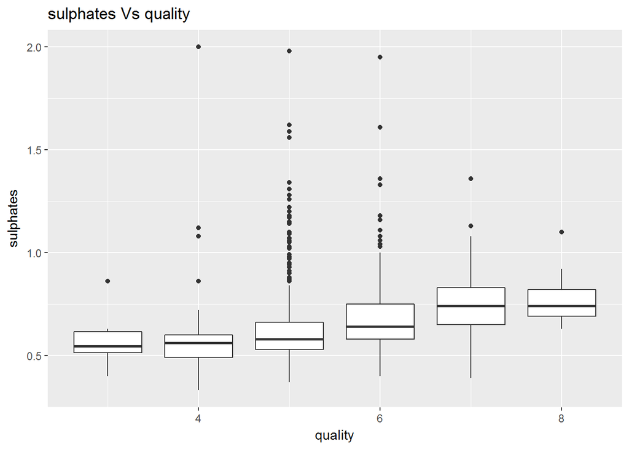

```r
#sulphates Vs quality

ggplot(aes(x=quality , y= sulphates,group=quality), data=df)+
  geom_boxplot()+ggtitle('sulphates Vs quality')
```

> That’s a suprise too. sulphates has a strong postive reltionship with Quality.

# Bivariate Analysis

1.Fixed Acidity doesnt have any co-realtion with Quality 2. Volatile Acidity has a negative co-relation with Quality 3. chlorides has weakly co-related with Quality 4. Residual sugar has no relation with Quality. Also the Average quality wines has a very high outliers 5. pH has a negative co-relation with Rating 6. Good Rating wines has more alcohol content 7. Citric Acid has a strong postive raltionship with Quality.

1. I was suprised with Citric Acid having a positive realtionship with Quality.
2. Also there are many outliers present in the distribution for most of the variables.

### What was the strongest relationship you found?

Citric Acid Vs Quality. Suplhates Vs Quality.

# Multivariate Plots Section

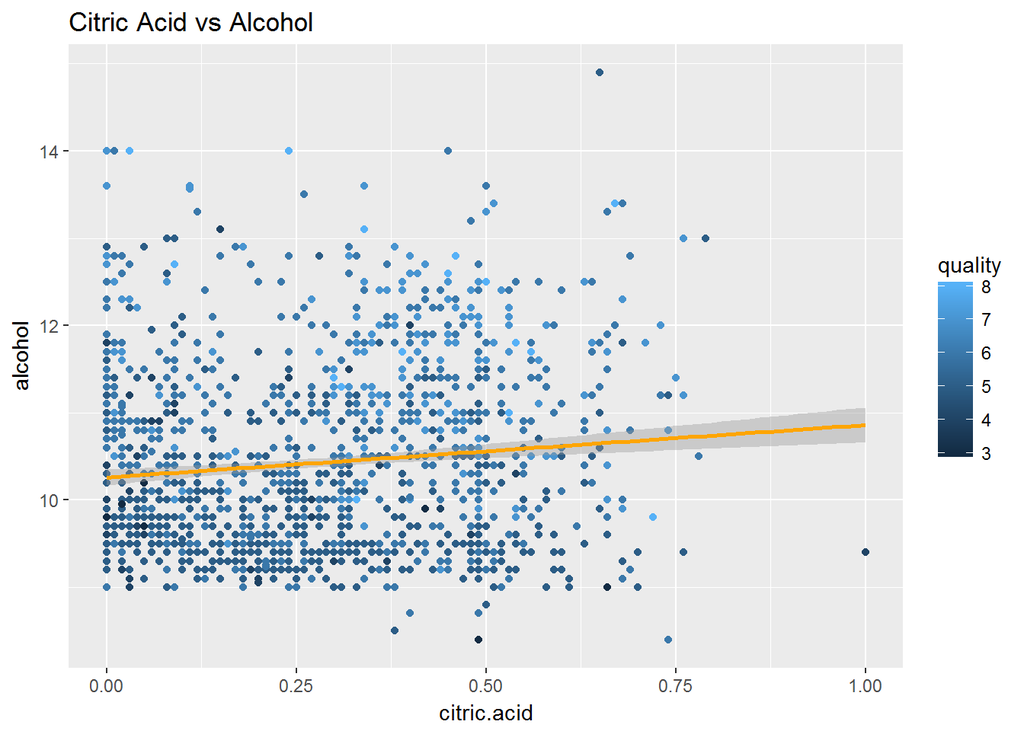

```r
#Citric Acid vs Alcohol

ggplot(aes(x=citric.acid,y=alcohol),data=df)+
  geom_point(aes(color=quality))+
  geom_smooth(method = 'lm' ,color='Orange')+
  ggtitle('Citric Acid vs Alcohol')
```

> There is no realtion between citric acid and alcohol. so let’s replot citirc acid with another acidic variable.

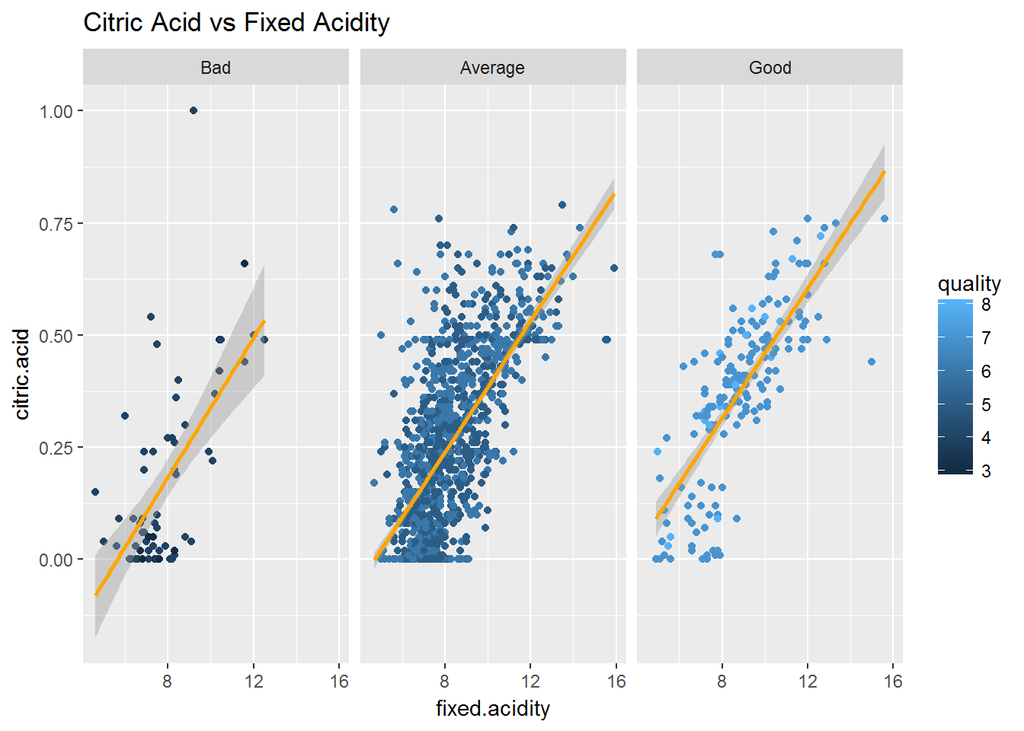

```r
#Citric Acid vs Fixed Acidity

ggplot(aes(x=fixed.acidity,y=citric.acid),data=df)+
  geom_point(aes(color=quality))+
  geom_smooth(method = 'lm' ,color='Orange')+
  facet_wrap(~df$rating)+
  ggtitle('Citric Acid vs Fixed Acidity')
```

> There is a positive corelaion between cirtic acid and Fixed Acidity either with respect to quality for Good wines.

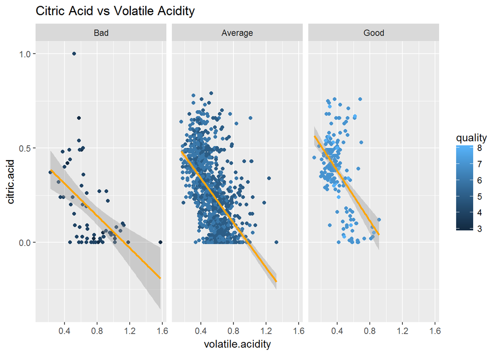

```r
#Citric Acid vs Volatile Acidity

ggplot(aes(x=volatile.acidity,y=citric.acid),data=df)+
  geom_point(aes(color=quality))+
  geom_smooth(method = 'lm' ,color='Orange')+
  facet_wrap(~df$rating)+
  ggtitle('Citric Acid vs Volatile Acidity')
```

> There is Negative corelaion between citric acid and Volatile Acidity with respect to quality.Also it shows lower volatile acidity and higher citric acid gives better wines.

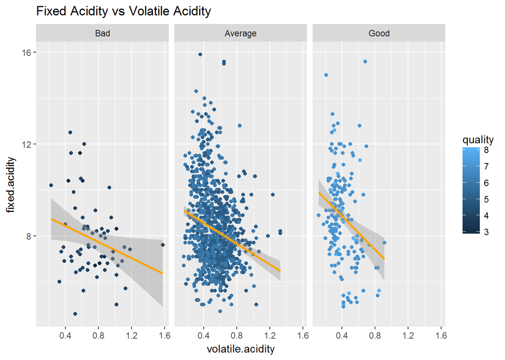

```r
#Fixed Acidity vs Volatile Acidity

ggplot(aes(x=volatile.acidity,y=fixed.acidity),data=df)+
  geom_point(aes(color=quality))+
  geom_smooth(method = 'lm' ,color='Orange')+
  facet_wrap(~df$rating)+
  ggtitle('Fixed Acidity vs Volatile Acidity')
```

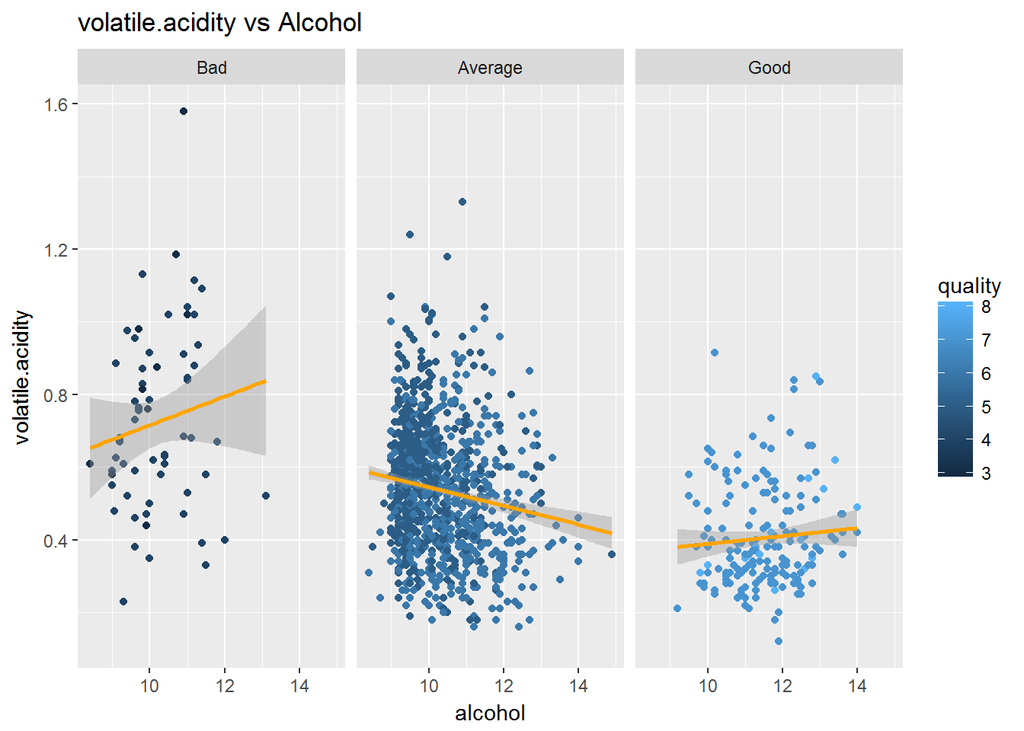

```r
#volatile.acidity vs Alcohol

ggplot(aes(x=alcohol,y=volatile.acidity),data=df)+
  geom_point(aes(color=quality))+
  geom_smooth(method = 'lm' ,color='Orange')+
  ggtitle('volatile.acidity vs Alcohol')+
  facet_wrap(~df$rating)
```

> If we look at the Good wines, They have very less volatile acidity. so we can predict, Lesser Volatile acid with more alcohol content make better wines.

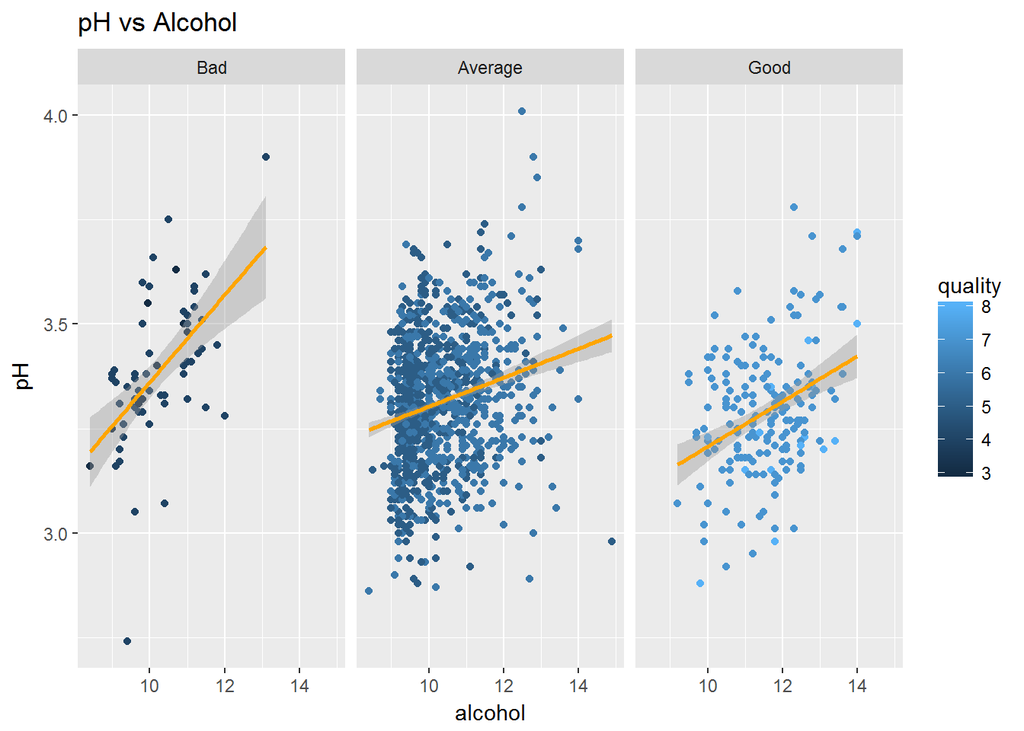

```r
#pH vs Alcohol

ggplot(aes(x=alcohol,y=pH),data=df)+
  geom_point(aes(color=quality))+
  geom_smooth(method = 'lm' ,color='Orange')+
  ggtitle('pH vs Alcohol')+
  facet_wrap(~df$rating)
```

> If we look at the Bad Rated wines, They have a positive corelation between pH and alcohol with respect to quality.

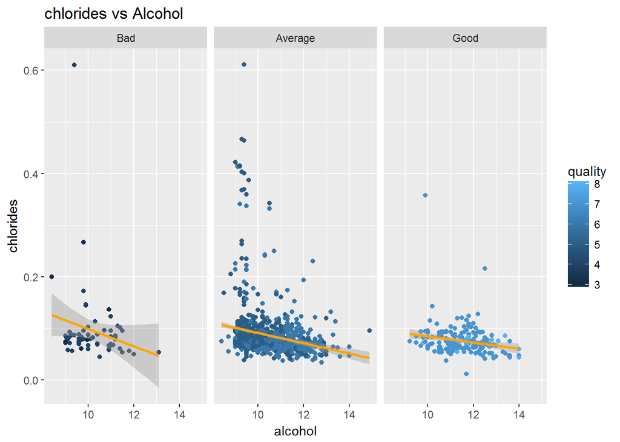

```r
#chlorides vs Alcohol

ggplot(aes(x=alcohol,y=chlorides),data=df)+
  geom_point(aes(color=quality))+
  geom_smooth(method = 'lm' ,color='Orange')+
  ggtitle('chlorides vs Alcohol')+
  facet_wrap(~df$rating)
```

> There is a negative corelation, low chlorides with high alcohol content make better wines.

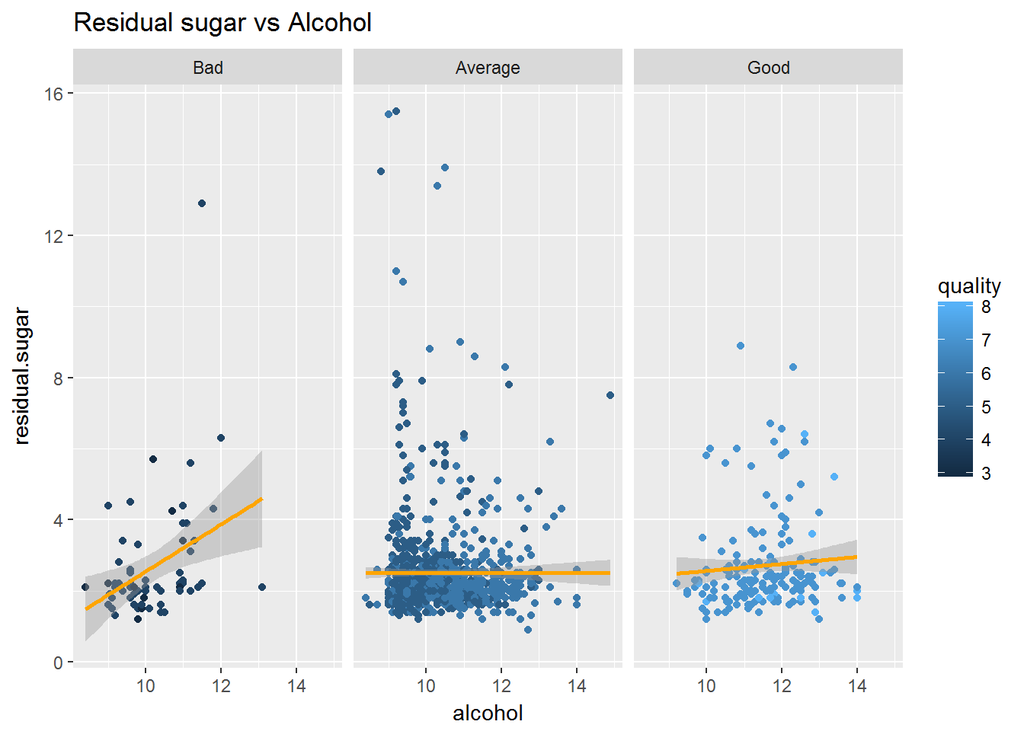

> There is no such corelation for Average and Good Quality wines.But for Bad Quality wines there is a postive corelation between residual sugar and alcohol.

# Multivariate Analysis

1. Low chlorides with high alcohol content make better wines.
2. Low Volatile acid with high alcohol content make better wines

1. There is Negative corelaion between citric acid and Volatile Acidity with respect to quality.Also it shows lower volatile acidity and higher citric acid gives better wines.
2. If we look at the Bad Rated wines, They have a positive corelation between pH and alcohol with respect to quality.

### Were there any interesting or surprising interactions between features?

# Final Plots and Summary

### PLOT 1: Influence of Citric Acid on Wine Quality

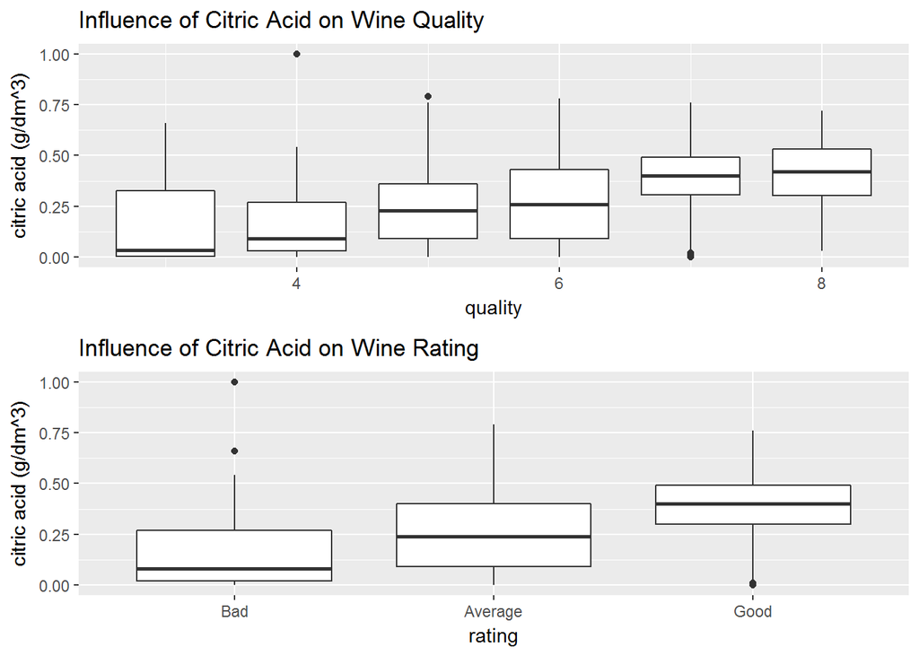

```r
#citric.acid Vs quality

p1 <- ggplot(aes(x=quality,y= citric.acid,group=quality),data=df)+
  geom_boxplot()+
  ggtitle('Influence of Citric Acid on Wine Quality')+
  xlab('quality')+
  ylab('citric acid (g/dm^3)')

p2 <- ggplot(aes(x=rating,y= citric.acid,group=rating),data=df)+
  geom_boxplot()+
  ggtitle('Influence of Citric Acid on Wine Rating')+
  xlab('rating')+
  ylab('citric acid (g/dm^3)')

grid.arrange(p1,p2)
```

### The Above plot tells us that citric acid does influences the wine quality.There is a postive corelation between them, As the higher the citric acid content better the red wine quality.

### PLOT 2: Influence of sulphates on Wine Quality

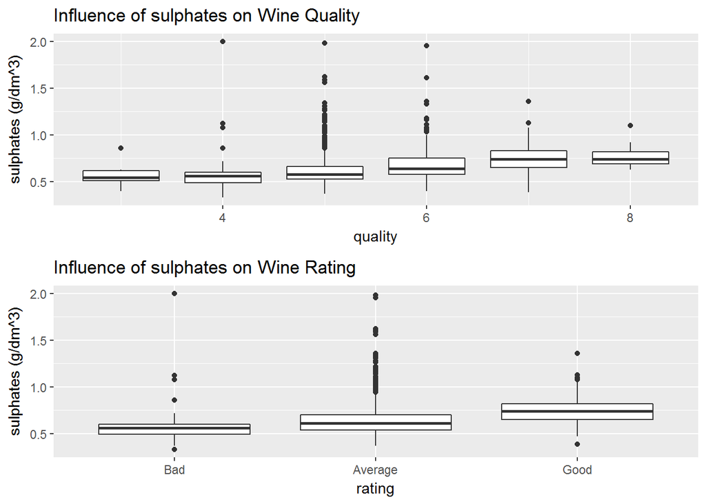

```r
#sulphates Vs quality

p1 <- ggplot(aes(x=quality,y= sulphates,group=quality),data=df)+
  geom_boxplot()+
  ggtitle('Influence of sulphates on Wine Quality')+
  xlab('quality')+
  ylab('sulphates (g/dm^3)')

p2 <- ggplot(aes(x=rating,y= sulphates,group=rating),data=df)+
  geom_boxplot()+
  ggtitle('Influence of sulphates on Wine Rating')+
  xlab('rating')+
  ylab('sulphates (g/dm^3)')

grid.arrange(p1,p2)
```

### The Above plot tells us that sulphates does influences the wine quality.There is a postive corelation between them, As the higher sulphates content better the red wine quality.

### PLOT 3: Influence of Chlorides and Alcohol over wine quality

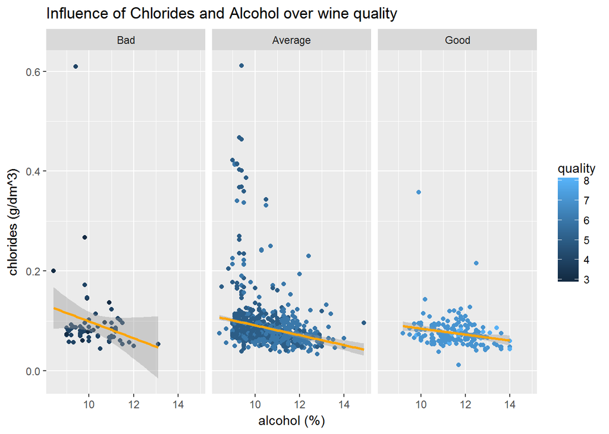

```r
#chlorides vs Alcohol

ggplot(aes(x=alcohol,y=chlorides),data=df)+
  geom_point(aes(color=quality))+
  geom_smooth(method = 'lm' ,color='Orange')+
  ggtitle('Influence of Chlorides and Alcohol over wine quality')+
  facet_wrap(~df$rating)+
  xlab('alcohol (%)')+
  ylab('chlorides (g/dm^3)')
```

### By Analyzing multivariate plots of chrolides and Alcohol over wine Quality.we can see a negative corealtion between chlorides and alcohol.As low chloride and high alcholic content make better wines.

# Reflection

> In this dataset,the main struggle i faced is with the outliers.Every feature has an outlier hence it formed a skewed distribution which certainly affects the analysis process unless we re-shape the feature by omiting the outliers. Also i have categorized the quality of wine by giving them rating as ‘Bad’,‘Average’ and ‘Good’ that helped my analysis work quite easily by predicting the behaviour of the features with respect to the rating of the wines. Also i have noticed pH is quite constant irespective of the quality of the wine.Also i have suprised with citric acid and sulphates having a postive corealtion with the quality of the wines.Intially for bivariant plots, I have plotted my dataset using scatter plot but it didnt give a good view of understanding, so i plotted box plot which helped me better to understand the realtionship between then features. Also in the future,i would like to take a wine dataset with more observations.As in this dataset most of the wines are fall under Average category and we had very less observations for Bad and Good Quality wines. Also i would like to analyze a wine dataset with more features as well,like the price and popularity and country orgin etc. So it will be interesting to analyze the dataset if we have much more unique information about each wines.